# GenoFunc

ID: ALS_only

# GWAS QC

This section provides some information from the sumstat quality control process and some descriptive statistics.

**Show sumstat_cleaner.R log file**

```
 [1] "#################################################################"
 [2] "# sumstat_cleaner.R"
 [3] "# For questions contact Oliver Pain (oliver.pain@kcl.ac.uk)"
 [4] "#################################################################"
 [5] "Analysis started at 2022-03-21 15:50:12 "
 [6] "Options are:"
 [7] "Options are:"
 [8] "$sumstats"
 [9] "[1] \"/users/k1806347/brc_scratch/Data/GWAS_sumstats/ALS/GWAS/ALS_sumstats_EUR_only_reformat.txt.gz\""
[10] ""
[11] "$ref_chr"
[12] "[1] \"resources/data/1kg/1KG.Phase3.EUR.MAF_001.chr\""
[13] ""
[14] "$info"
[15] "[1] 0.9"
```

[output cut: 39 more lines]

**Show FOCUS munge log file**

```
 [1] "==================================="
 [2] "              FOCUS v0.6.10            "
 [3] "==================================="
 [4] "focus munge"
 [5] "\tresources/data/gwas_sumstat/ALS2021/ALS2021.cleaned.gz"
 [6] "\t--output resources/data/gwas_sumstat/ALS2021/ALS2021.cleaned.munged"
 [7] ""
 [8] "Starting log..."
 [9] "[2022-03-21 18:25:01 - INFO] Interpreting column names as follows:"
[10] "[2022-03-21 18:25:01 - INFO] SNP: Variant ID (e.g., rs number)"
[11] "[2022-03-21 18:25:01 - INFO] CHR: Chromsome"
[12] "[2022-03-21 18:25:01 - INFO] BETA: [linear/logistic] regression coefficient (0 --> no effect; above 0 --> A1 is trait/risk increasing)"
[13] "[2022-03-21 18:25:01 - INFO] P: p-Value"
[14] "[2022-03-21 18:25:01 - INFO] N: Sample size"
[15] "[2022-03-21 18:25:01 - INFO] A1: Allele 1, interpreted as ref allele for signed sumstat"
```

[output cut: 22 more lines]

Full results file: resources/data/gwas_sumstat/ALS_only/ALS_only.cleaned.munged.log

# SNP-based Heritability

This section shows the output from [LD-score regression](https://github.com/bulik/ldsc), including an estimate of SNP-based heritability on the observed scale, and the LD-score regression intercept. The intercept can be used to determine whether there is genome-wide inflation that is not explained by high polygenicity.

**Show LDSC log file**

```
 [1] "*********************************************************************"
 [2] "* LD Score Regression (LDSC)"
 [3] "* Version 1.0.1"
 [4] "* (C) 2014-2019 Brendan Bulik-Sullivan and Hilary Finucane"
 [5] "* Broad Institute of MIT and Harvard / MIT Department of Mathematics"
 [6] "* GNU General Public License v3"
 [7] "*********************************************************************"
 [8] "Call: "
 [9] "./ldsc.py \\"
[10] "--h2 resources/data/gwas_sumstat/ALS_only/ALS_only.cleaned.munged.sumstats.gz \\"
[11] "--ref-ld-chr resources/data/ldsc/eur_w_ld_chr/ \\"
[12] "--out results/ALS_only/ldsc/ALS_only_ldsc_res \\"
[13] "--w-ld-chr resources/data/ldsc/eur_w_ld_chr/ "
[14] ""
[15] "Beginning analysis at Wed Aug  3 15:33:42 2022"
```

[output cut: 17 more lines]

Full results file: results/ALS_only/ldsc/ALS_only_ldsc_res.log

# SNP associations

This section list independent SNP associations achieving either genome-wide or suggestive significance. Independence is determined using [LD-based clumping](https://www.cog-genomics.org/plink/1.9/postproc#clump) and/or conditional-joint (COJO analysis. Note, LD is estimated using a reference sample and may not accurately reflect the LD structure in the GWAS sample. COJO analysis is particularly sensitive to LD mispecification.

**Clumped: GW-significant loci**

GWAS contain 17 independent (r2 < 0.1, 500kb) genome-wide significant variants (p < 5e-8).

| CHR | BP | SNP | A1 | A2 | BETA | SE | P | FREQ | REF.FREQ | N | NearestGene |
| --- | --- | --- | --- | --- | --- | --- | --- | --- | --- | --- | --- |
| 3 | 39508968 | rs631312 | A | G | -0.0791 | 0.012 | 5.24e-11 | 0.7087 | 0.6958 | 80713 | MOBP, AC099332.1 (+49.91kb) |
| 5 | 150410835 | rs10463311 | T | C | -0.0792 | 0.0126 | 3.46e-10 | 0.7474 | 0.7286 | 80713 | TNIP1, GPX3 (+2.28kb) |
| 5 | 172354731 | rs517339 | T | C | 0.0645 | 0.0112 | 8.46e-09 | 0.6034 | 0.6133 | 80713 | ERGIC1, CTC-308K20.1 (-27.06kb), CTC-308K20.2 (-27.18kb), RPL26L1 (-31kb), CTC-308K20.3 (-47.78kb) |
| 6 | 31606392 | rs2077492 | A | G | 0.0612 | 0.0111 | 3.35e-08 | 0.4928 | 0.5179 | 80713 | BAG6 (-0.41kb), PRRC2A (+0.84kb), APOM (-13.8kb), SNORA38 (+15.4kb), C6orf47 (-19.68kb), C6orf47-AS1 (-19.71kb), AIF1 (+21.59kb), GPANK1 (-22.61kb), Y_RNA (-24.67kb), CSNK2B (-26.62kb), UQCRHP1 (+27.2… |
| 6 | 32672641 | rs9275477 | A | C | 0.1426 | 0.0207 | 5.50e-12 | 0.9036 | 0.8956 | 80713 | MTCO3P1 (-1.26kb), XXbac-BPG254F23.7 (-13.14kb), HLA-DQB3 (-25.89kb), HLA-DQA2 (-36.48kb), HLA-DQB1 (+36.48kb), XXbac-BPG254F23.6 (+42.41kb), HLA-DQB1-AS1 (+44.13kb), MIR3135B (-45.05kb) |
| 9 | 27466684 | rs10121017 | A | G | -0.0756 | 0.0131 | 8.41e-09 | 0.4337 | 0.4245 | 73213 | MOB3B |
| 9 | 27563868 | rs2453555 | A | G | 0.1736 | 0.0127 | 9.98e-43 | 0.2475 | 0.2326 | 80713 | C9orf72, MOB3B (+34.09kb), IFNK (+37.37kb), CTAGE12P (-44.51kb) |
| 9 | 27585697 | rs36062268 | A | G | 0.1479 | 0.0194 | 2.37e-14 | 0.1084 | 0.08847 | 80713 | C9orf72 (+11.83kb), CTAGE12P (-22.68kb) |
| 9 | 27675210 | rs11789832 | T | C | 0.2647 | 0.0469 | 1.69e-08 | 0.0173 | 0.01392 | 80713 | None |
| 12 | 57975700 | rs113247976 | T | C | 0.3322 | 0.0492 | 1.42e-11 | 0.0155 | 0.02386 | 80713 | KIF5A, PIP4K2C (-9.26kb), DTX3 (-22.7kb), ARHGEF25 (-28.26kb), AC025165.8 (-30.2kb), DCTN2 (+34.59kb), SLC26A10 (-37.61kb), B4GALNT1 (-41.49kb) |

[output cut: 7 more lines]

Full results file: results/ALS_only/clump/ALS_only.GW.clump.clean.csv

Note. CHR = Chromsome; BP = Basepair position; SNP = Variant ID; A1 = Allele 1 (effect allele); A2 = Allele 2 (reference allele); BETA = Effect size; SE = Standard error; P = p-value; FREQ = Frequency of allele 1 reported in GWAS; REF.FREQ = Frequency of allele 1 reported in ancestry matched reference population; N = Sample size; NearestGene = Nearest genes to lead variant with distance in parentheses

**Clumped: Suggestive loci**

Clumping finds 83 independent (r2 < 0.1, 500kb) suggestive significant variants (p < 1e-5).

| CHR | BP | SNP | A1 | A2 | BETA | SE | P | FREQ | REF.FREQ | N | NearestGene |
| --- | --- | --- | --- | --- | --- | --- | --- | --- | --- | --- | --- |
| 1 | 14150714 | rs2744680 | A | G | -0.0667 | 0.0149 | 7.40e-06 | 0.8343 | 0.8479 | 80713 | PRDM2 |
| 1 | 97167390 | rs7554259 | A | G | 0.049 | 0.011 | 7.83e-06 | 0.4835 | 0.4602 | 80713 | RN7SKP270 (+5.67kb), PTBP2 (-19.83kb), RPL7P9 (+22.21kb) |
| 1 | 167426424 | rs1214598 | A | G | -0.0555 | 0.0117 | 2.25e-06 | 0.371 | 0.3469 | 80713 | CD247, RP11-104L21.2 (-0.2kb), RP11-104L21.3 (-0.56kb), POU2F1 (+29.84kb) |
| 1 | 215228234 | rs12131054 | T | C | 0.0515 | 0.0116 | 9.46e-06 | 0.3281 | 0.338 | 80713 | KCNK2 |
| 1 | 224424442 | rs1976788 | A | G | -0.0777 | 0.016 | 1.22e-06 | 0.1448 | 0.1461 | 80713 | NVL, RP11-365O16.6 (+8.7kb), MIR320B2 (-20.26kb), RP11-365O16.3 (+23.46kb), DEGS1 (+43.3kb) |
| 2 | 220201272 | rs4674377 | T | G | 0.0618 | 0.0122 | 4.27e-07 | 0.7148 | 0.7147 | 80713 | RESP18 (+3.37kb), AC053503.2 (-22.32kb), PTPRN (+26.9kb), AC114803.3 (+32.42kb), DNPEP (-37kb), MIR153-1 (+42.35kb), DNAJB2 (+49.65kb) |
| 3 | 39508968 | rs631312 | A | G | -0.0791 | 0.012 | 5.24e-11 | 0.7087 | 0.6958 | 80713 | MOBP, AC099332.1 (+49.91kb) |
| 3 | 47835889 | rs34711187 | T | C | -0.1077 | 0.0198 | 5.73e-08 | 0.0899 | 0.0825 | 80713 | DHX30 (-8.51kb), SMARCC1 (+12.29kb), AC026318.1 (+25.19kb) |
| 3 | 93522006 | rs146358369 | A | G | 0.0963 | 0.0185 | 1.85e-07 | 0.1291 | 0.1292 | 80713 | RNU6-488P (-40.6kb) |
| 4 | 925376 | rs873786 | T | C | -0.1139 | 0.0215 | 1.26e-07 | 0.0988 | 0.09642 | 69810 | GAK, TMEM175 (-0.8kb), DGKQ (-27.3kb), SLC26A1 (-47.48kb) |

[output cut: 73 more lines]

Full results file: results/ALS_only/clump/ALS_only.GW.clump.clean.csv

Note. CHR = Chromsome; BP = Basepair position; SNP = Variant ID; A1 = Allele 1 (effect allele); A2 = Allele 2 (reference allele); BETA = Effect size; SE = Standard error; P = p-value; FREQ = Frequency of allele 1 reported in GWAS; REF.FREQ = Frequency of allele 1 reported in ancestry matched reference population; N = Sample size; NearestGene = Nearest genes to lead variant with distance in parentheses

**COJO: GW-significant loci**

COJO finds 11 independent genome-wide significant variants (p < 5e-8).

| CHR | BP | SNP | A1 | A2 | BETA | SE | P | FREQ | REF.FREQ | N | NearestGene |
| --- | --- | --- | --- | --- | --- | --- | --- | --- | --- | --- | --- |
| 3 | 39508968 | rs631312 | A | G | -0.0791 | 0.012 | 5.24e-11 | 0.7087 | 0.6958 | 80713 | MOBP, AC099332.1 (+49.91kb) |
| 5 | 150410835 | rs10463311 | T | C | -0.0792 | 0.0126 | 3.46e-10 | 0.7474 | 0.7286 | 80713 | TNIP1, GPX3 (+2.28kb) |
| 5 | 172354731 | rs517339 | T | C | 0.0645 | 0.0112 | 8.46e-09 | 0.6034 | 0.6133 | 80713 | ERGIC1, CTC-308K20.1 (-27.06kb), CTC-308K20.2 (-27.18kb), RPL26L1 (-31kb), CTC-308K20.3 (-47.78kb) |
| 6 | 32672641 | rs9275477 | A | C | 0.1426 | 0.0207 | 5.50e-12 | 0.9036 | 0.8956 | 80713 | MTCO3P1 (-1.26kb), XXbac-BPG254F23.7 (-13.14kb), HLA-DQB3 (-25.89kb), HLA-DQA2 (-36.48kb), HLA-DQB1 (+36.48kb), XXbac-BPG254F23.6 (+42.41kb), HLA-DQB1-AS1 (+44.13kb), MIR3135B (-45.05kb) |
| 9 | 27561800 | rs2453554 | T | C | 0.1723 | 0.0126 | 2.56e-42 | 0.2482 | 0.2356 | 80713 | C9orf72, MOB3B (+32.02kb), IFNK (+35.3kb), CTAGE12P (-46.58kb) |
| 12 | 57975700 | rs113247976 | T | C | 0.3322 | 0.0492 | 1.42e-11 | 0.0155 | 0.02386 | 80713 | KIF5A, PIP4K2C (-9.26kb), DTX3 (-22.7kb), ARHGEF25 (-28.26kb), AC025165.8 (-30.2kb), DCTN2 (+34.59kb), SLC26A10 (-37.61kb), B4GALNT1 (-41.49kb) |
| 12 | 64749141 | rs61931525 | T | C | 0.099 | 0.0173 | 1.12e-08 | 0.883 | 0.8748 | 80713 | RPS11P6, C12orf56, snoU13 (-0.4kb), RP11-114F3.2 (+16.56kb), XPOT (-48.99kb) |
| 14 | 31078502 | rs2045180 | A | G | 0.0922 | 0.0118 | 5.70e-15 | 0.3353 | 0.3519 | 80713 | G2E3, SCFD1 (-12.82kb), RP11-1103G16.1 (+35.67kb) |
| 19 | 17752689 | rs12608932 | A | C | -0.1247 | 0.0121 | 8.77e-25 | 0.6528 | 0.6511 | 73213 | UNC13A, CTD-3149D2.3 (+27.45kb) |
| 20 | 48493927 | rs2869935 | A | G | -0.0719 | 0.0116 | 6.53e-10 | 0.6473 | 0.6372 | 80713 | SLC9A8, SPATA2 (-26kb), Y_RNA (-43.21kb), RP5-1041C10.3 (+46.3kb), RNU7-72P (+49.34kb) |

[output cut: 1 more lines]

Full results file: results/ALS_only/cojo/ALS_only.GW.cojo.clean.csv

Note. CHR = Chromsome; BP = Basepair position; SNP = Variant ID; A1 = Allele 1 (effect allele); A2 = Allele 2 (reference allele); BETA = Effect size; SE = Standard error; P = p-value; FREQ = Frequency of allele 1 reported in GWAS; REF.FREQ = Frequency of allele 1 reported in ancestry matched reference population; N = Sample size; NearestGene = Nearest genes to lead variant with distance in parentheses

**COJO: Suggestive loci**

COJO finds 61 independent suggestive significant variants (p < 1e-5).

| CHR | BP | SNP | A1 | A2 | BETA | SE | P | FREQ | REF.FREQ | N | NearestGene |
| --- | --- | --- | --- | --- | --- | --- | --- | --- | --- | --- | --- |
| 1 | 14150714 | rs2744680 | A | G | -0.0667 | 0.0149 | 7.40e-06 | 0.8343 | 0.8479 | 80713 | PRDM2 |
| 1 | 97151495 | rs17524886 | T | C | -0.0491 | 0.011 | 7.95e-06 | 0.5154 | 0.5378 | 80713 | RPL7P9 (+6.32kb), RN7SKP270 (-9.92kb), PTBP2 (-35.73kb) |
| 1 | 167426424 | rs1214598 | A | G | -0.0555 | 0.0117 | 2.25e-06 | 0.371 | 0.3469 | 80713 | CD247, RP11-104L21.2 (-0.2kb), RP11-104L21.3 (-0.56kb), POU2F1 (+29.84kb) |
| 1 | 224424442 | rs1976788 | A | G | -0.0777 | 0.016 | 1.22e-06 | 0.1448 | 0.1461 | 80713 | NVL, RP11-365O16.6 (+8.7kb), MIR320B2 (-20.26kb), RP11-365O16.3 (+23.46kb), DEGS1 (+43.3kb) |
| 2 | 220201272 | rs4674377 | T | G | 0.0618 | 0.0122 | 4.27e-07 | 0.7148 | 0.7147 | 80713 | RESP18 (+3.37kb), AC053503.2 (-22.32kb), PTPRN (+26.9kb), AC114803.3 (+32.42kb), DNPEP (-37kb), MIR153-1 (+42.35kb), DNAJB2 (+49.65kb) |
| 3 | 39508968 | rs631312 | A | G | -0.0791 | 0.012 | 5.24e-11 | 0.7087 | 0.6958 | 80713 | MOBP, AC099332.1 (+49.91kb) |
| 3 | 47835889 | rs34711187 | T | C | -0.1077 | 0.0198 | 5.73e-08 | 0.0899 | 0.0825 | 80713 | DHX30 (-8.51kb), SMARCC1 (+12.29kb), AC026318.1 (+25.19kb) |
| 3 | 93522006 | rs146358369 | A | G | 0.0963 | 0.0185 | 1.85e-07 | 0.1291 | 0.1292 | 80713 | RNU6-488P (-40.6kb) |
| 4 | 925376 | rs873786 | T | C | -0.1139 | 0.0215 | 1.26e-07 | 0.0988 | 0.09642 | 69810 | GAK, TMEM175 (-0.8kb), DGKQ (-27.3kb), SLC26A1 (-47.48kb) |
| 4 | 951947 | rs34311866 | T | C | -0.0763 | 0.0153 | 5.84e-07 | 0.8141 | 0.8131 | 73213 | TMEM175, DGKQ (-0.73kb), SLC26A1 (-20.91kb), GAK (+25.79kb), IDUA (-28.84kb) |

[output cut: 51 more lines]

Full results file: results/ALS_only/cojo/ALS_only.GW.cojo.clean.csv

Note. CHR = Chromsome; BP = Basepair position; SNP = Variant ID; A1 = Allele 1 (effect allele); A2 = Allele 2 (reference allele); BETA = Effect size; SE = Standard error; P = p-value; FREQ = Frequency of allele 1 reported in GWAS; REF.FREQ = Frequency of allele 1 reported in ancestry matched reference population; N = Sample size; NearestGene = Nearest genes to lead variant with distance in parentheses

## SNP Finemapping

This section summarises the results SNP-based statistical finemapping, using the software [SuSiE](https://stephenslab.github.io/susie-paper/). Note, LD is estimated using a reference sample and may not accurately reflect the LD structure in the GWAS sample. Finemapping analysis with multiple causal variants (L>1) is particularly sensitive to LD mispecification. Below we also provide finemapping results assuming a single causal variant (i.e. L=1), which is robust to LD mispecification but has reduced power when more than one causal variant is present.

**Finemapping (L<10): All loci**

| CHR | BP | SNP | cs | NSNP | TopPIP | Gene |
| --- | --- | --- | --- | --- | --- | --- |
| 3 | 39508968 | rs631312 | 1 | 11 | 0.46 | None |
| 5 | 150410835 | rs10463311 | 1 | 7 | 0.59 | None |
| 5 | 172354731 | rs517339 | 1 | 11 | 0.14 | ERGIC1 |
| 6 | 32672641 | rs9275477 | 1 | 31 | 0.5 | None |
| 9 | 27466684 | rs10121017 | 2 | 2 | 0.58 | MOB3B |
| 9 | 27466684 | rs10121017 | 1 | 7 | 0.27 | None |
| 9 | 27563868 | rs2453555 | 2 | 2 | 0.58 | MOB3B |
| 9 | 27563868 | rs2453555 | 1 | 7 | 0.27 | None |
| 9 | 27585697 | rs36062268 | 2 | 2 | 0.58 | MOB3B |
| 9 | 27585697 | rs36062268 | 1 | 7 | 0.27 | None |

[output cut: 10 more lines]

Full results file: results/ALS_only/finemap/ALS_only.GW.finemap.csv

Note. CHR = Chromsome; BP = Basepair position; SNP = Variant ID; cs = Credible set number; NSNP = Number of SNPs in 95% credible set; TopPIP = Highest posterior inclusion probability of variants within 95% credible set; Gene = Genes boundaries (0kb window) contain all variants within 95% credible set.

**Finemapping (L=1): All loci**

| CHR | BP | SNP | cs | NSNP | TopPIP | Gene |
| --- | --- | --- | --- | --- | --- | --- |
| 3 | 39508968 | rs631312 | 1 | 11 | 0.46 | None |
| 5 | 150410835 | rs10463311 | 1 | 7 | 0.6 | None |
| 5 | 172354731 | rs517339 | 1 | 15 | 0.13 | ERGIC1 |
| 6 | 32672641 | rs9275477 | 1 | 32 | 0.48 | None |
| 9 | 27466684 | rs10121017 | 1 | 9 | 0.25 | None |
| 9 | 27563868 | rs2453555 | 1 | 9 | 0.25 | None |
| 9 | 27585697 | rs36062268 | 1 | 9 | 0.25 | None |
| 9 | 27675210 | rs11789832 | 1 | 9 | 0.25 | None |
| 12 | 57975700 | rs113247976 | 1 | 1 | 1 | KIF5A |
| 12 | 58656105 | rs116900480 | 1 | 1 | 0.97 | None |

[output cut: 6 more lines]

Full results file: results/ALS_only/finemap/ALS_only.GW.finemap.csv

Note. CHR = Chromsome; BP = Basepair position; SNP = Variant ID; cs = Credible set number; NSNP = Number of SNPs in 95% credible set; TopPIP = Highest posterior inclusion probability of variants within 95% credible set; Gene = Genes boundaries (+/- 10kb) all variants within 95% credible set.

# Molecular associations

This section summarises analyses that infer molecular changes associated with the GWAS phenotype, either altered gene expression or protein levels. We integrate a range of datasets indicating the effect of genetic variants on expression and protein levels in different tissues. Depending on the availability of data, we run the analysis using [FUSION](http://gusevlab.org/projects/fusion/) or [SMR](https://yanglab.westlake.edu.cn/software/smr/#Overview)

**Show list of molecular datasets included**

| Type | Software | Panel | N_indiv | N_gene |
| --- | --- | --- | --- | --- |
| Expression | FUSION | Brain - Amygdala (GTEx) | 119 | 2513 |
| Expression | FUSION | Brain - Anterior cingulate cortex BA24 (GTEx) | 135 | 3326 |
| Expression | FUSION | Brain - Caudate basal ganglia (GTEx) | 172 | 4884 |
| Expression | FUSION | Brain - Cerebellar hemisphere (GTEx) | 157 | 5885 |
| Expression | FUSION | Brain - Cerebellum (GTEx) | 188 | 7050 |
| Expression | FUSION | Brain - Cortex (GTEx) | 183 | 5425 |
| Expression | FUSION | Brain - Frontal cortex BA9 (GTEx) | 157 | 4388 |
| Expression | FUSION | Brain - Hippocampus (GTEx) | 150 | 3437 |
| Expression | FUSION | Brain - Hypothalamus (GTEx) | 156 | 3423 |
| Expression | FUSION | Brain - Nucleus accumbens basal ganglia (GTEx) | 181 | 4830 |

[output cut: 20 more lines]

## Expression

### All TWAS panels

**TWAS: FDR significant and colocalised results**

| CHR | P0 | P1 | Ensembl ID | Gene Symbol | PANEL | TWAS.Z | TWAS.P | TWAS.P.FDR | COLOC.PP3 | COLOC.PP4 |
| --- | --- | --- | --- | --- | --- | --- | --- | --- | --- | --- |
| 1 | 2357419 | 2436969 | ENSG00000149527 | PLCH2 | Brain - Cerebellum (GTEx) | -4.263 | 2.02e-05 | 1.16e-02 | 0.002 | 0.033 |
| 1 | 17300997 | 17307330 | ENSG00000117122 | MFAP2 | Brain - Hippocampus (GTEx) | -4.293 | 1.76e-05 | 1.14e-02 | 0.001 | 0.665 |
| 1 | 17345217 | 17380665 | ENSG00000117118 | SDHB | Brain - Cortex (GTEx) | -3.909 | 9.25e-05 | 3.39e-02 | 0.004 | 0.784 |
| 1 | 120161999 | 120190390 | ENSG00000143067 | ZNF697 | Brain - DLPFC (CMC) | 3.771 | 1.63e-04 | 4.92e-02 | 0.008 | 0.354 |
| 1 | 151043054 | 151098018 | ENSG00000143458 | GABPB2 | Blood (GTEx) | 3.915 | 9.03e-05 | 3.35e-02 | 0.001 | 0.81 |
| 1 | 151043054 | 151098018 | ENSG00000143458 | GABPB2 | Brain - DLPFC (PsychENCODE) | 3.94 | 8.10e-05 | 3.05e-02 | 0.004 | 0.737 |
| 1 | 167399877 | 167487847 | ENSG00000198821 | CD247 | Blood (YFS) | -4.661 | 3.15e-06 | 3.10e-03 | 0.003 | 0.989 |
| 1 | 224396449 | 224400981 | ENSG00000232628 | RP11-365O16.3 | Brain - Spinal cord vervical c-1 (GTEx) | -4.104 | 4.05e-05 | 1.90e-02 | 0.064 | 0.334 |
| 2 | 201754050 | 201768655 | ENSG00000196290 | NIF3L1 | Brain - Nucleus accumbens basal ganglia (GTEx) | -3.798 | 1.46e-04 | 4.59e-02 | 0.002 | 0.036 |
| 2 | 219502639 | 219524378 | ENSG00000115568 | ZNF142 | Brain - Cortex (GTEx) | 4.3 | 1.71e-05 | 1.12e-02 | 0.024 | 0.173 |

[output cut: 187 more lines]

TWAS contain 197 transcriptome-wide significant and colocalised associations, including 101 unique genes.

Full results file: results/ALS_only/twas/ALS_only_twas_GW_clean.txt.gz

Note. CHR = Chromsome; P0 = Gene start; P1 = Gene end; PANEL = Gene expression panel; TWAS.Z = TWAS Z-score; TWAS.P = TWAS p-value; TWAS.P.FDR = BY FDR corrected TWAS p-value; COLOC.PP3 = Posterior probability of coloc model 3 (linkage); COLOC.PP4 = Posterior probability of coloc model 4 (pleiotropy).

**TWAS: Full conditional analysis results**

| CHR | BP | JOINT.ID | MARGIN.ID | BEST.TWAS.P | BEST.SNP.P | VAR.EXP |
| --- | --- | --- | --- | --- | --- | --- |
| 1 | 1359351-3342128 | PLCH2 (Brain_Cerebellum) | - | 2.02e-05 | 8.91e-04 | 92.5% |
| 1 | 16308809-18378569 | MFAP2 (Brain_Hippocampus) | SDHB (Brain_Cortex) | 1.76e-05 | 1.76e-05 | 85.7% |
| 1 | 119165688-121159164 | ZNF697 (CMC.BRAIN.RNASEQ) | - | 1.63e-04 | 4.64e-04 | 54% |
| 1 | 150043471-152042512 | GABPB2 (Whole_Blood) | - | 9.03e-05 | 1.06e-04 | 96.4% |
| 1 | 154025193-156019075 | ADAM15 (Whole_Blood) | - | 1.59e-04 | 6.29e-04 | 99.5% |
| 1 | 166401936-168482414 | CD247 (YFS.BLOOD.RNAARR) | - | 3.15e-06 | 2.25e-06 | 75.3% |
| 1 | 223402382-225400860 | RP11-365O16.3 (Brain_Spinal_cord_cervical_c-1) | - | 4.05e-05 | 1.22e-06 | 65.2% |
| 2 | 200754346-202752474 | NIF3L1 (Brain_Nucleus_accumbens_basal_ganglia) | - | 1.46e-04 | 1.15e-03 | -24.7% |
| 2 | 218507099-221197309 | AC097468.7 (Brain_Cortex), CYP27A1 (Whole_Blood), RESP18 (kcl_brainbank_motor_cortex) | RESP18 (Brain_Amygdala, Brain_Anterior_cingulate_cortex_BA24, Brain_Caudate_basal_ganglia, Brain_Cerebellar_Hemisphere, Brain_Cortex, Brain_Frontal_Cortex_BA9, Brain_Hippocampus, Brain_Hypothalamus, B… | 3.93e-07 | 4.26e-07 | 98.8% |
| 3 | 93505359-94778050 | ARL13B (CMC.BRAIN.RNASEQ_SPLICING) | DHFRL1 (CMC.BRAIN.RNASEQ) | 2.58e-06 | 1.86e-07 | 73.2% |

[output cut: 45 more lines]

Full results file: results/ALS_only/twas/conditional/ALS_only_twas_conditional_clean_full.csv

Note. CHR = Chromsome; BP = Basepair position range of locus; JOINT.ID = Features remaining significiant in joint model of significant features in locus; MARGIN.ID = Features not significiant in joint model of significant features in locus; BEST.TWAS.P = P-value of most significant feature within locus; BEST.SNP.P = P-value of most significant variant within locus; VAR.EXP = Variance in SNP-phenotype associations explained by jointly significant TWAS features.

**TWAS: Brief conditional analysis results**

| CHR | BP | JOINT.ID | MARGIN.N | BEST.TWAS.P | BEST.SNP.P | VAR.EXP |
| --- | --- | --- | --- | --- | --- | --- |
| 1 | 1359351-3342128 | PLCH2 (Brain_Cerebellum) | 0 | 2.02e-05 | 8.91e-04 | 92.5% |
| 1 | 16308809-18378569 | MFAP2 (Brain_Hippocampus) | 1 | 1.76e-05 | 1.76e-05 | 85.7% |
| 1 | 119165688-121159164 | ZNF697 (CMC.BRAIN.RNASEQ) | 0 | 1.63e-04 | 4.64e-04 | 54% |
| 1 | 150043471-152042512 | GABPB2 (Whole_Blood) | 0 | 9.03e-05 | 1.06e-04 | 96.4% |
| 1 | 154025193-156019075 | ADAM15 (Whole_Blood) | 0 | 1.59e-04 | 6.29e-04 | 99.5% |
| 1 | 166401936-168482414 | CD247 (YFS.BLOOD.RNAARR) | 0 | 3.15e-06 | 2.25e-06 | 75.3% |
| 1 | 223402382-225400860 | RP11-365O16.3 (Brain_Spinal_cord_cervical_c-1) | 0 | 4.05e-05 | 1.22e-06 | 65.2% |
| 2 | 200754346-202752474 | NIF3L1 (Brain_Nucleus_accumbens_basal_ganglia) | 0 | 1.46e-04 | 1.15e-03 | -24.7% |
| 2 | 218507099-221197309 | AC097468.7 (Brain_Cortex), CYP27A1 (Whole_Blood), RESP18 (kcl_brainbank_motor_cortex) | 17 | 3.93e-07 | 4.26e-07 | 98.8% |
| 3 | 93505359-94778050 | ARL13B (CMC.BRAIN.RNASEQ_SPLICING) | 1 | 2.58e-06 | 1.86e-07 | 73.2% |

[output cut: 45 more lines]

Full results file: results/ALS_only/twas/conditional/ALS_only_twas_conditional_clean_brief.csv

Note. CHR = Chromsome; BP = Basepair position range of locus; JOINT.ID = Features remaining significiant in joint model of significant features in locus; MARGIN.N = Number of features not significiant in joint model of significant features in locus; BEST.TWAS.P = P-value of most significant feature within locus; BEST.SNP.P = P-value of most significant variant within locus; VAR.EXP = Variance in SNP-phenotype associations explained by jointly significant TWAS features.

**TWAS: Detailed results**

| CHR | BP | P0 | P1 | ID | PANEL | TWAS.Z | TWAS.P | BEST.GWAS.P | TOP.SNP.COR | Type | Novel | COLOC.PP3 | COLOC.PP4 | Colocalised |
| --- | --- | --- | --- | --- | --- | --- | --- | --- | --- | --- | --- | --- | --- | --- |
| 1 | 2357419-2436969 | 2357419 | 2436969 | PLCH2 | Brain_Cerebellum | -4.26278 | 2.02e-05 | 1.15e-03 | -0.61 | Joint | Yes | 0.002 | 0.033 | False |
| 1 | 17300997-17307330 | 17300997 | 17307330 | MFAP2 | Brain_Hippocampus | -4.293 | 1.76e-05 | 1.79e-05 | -0.75 | Joint | Yes | 0.001 | 0.665 | False |
| 1 | 17345217-17380665 | 17345217 | 17380665 | SDHB | Brain_Cortex | -3.90934 | 9.25e-05 | 1.79e-05 | -0.94 | Marginal | Yes | 0.004 | 0.784 | False |
| 1 | 120161999-120190390 | 120161999 | 120190390 | ZNF697 | CMC.BRAIN.RNASEQ | 3.77069 | 1.63e-04 | 6.50e-04 | -0.33 | Joint | Yes | 0.008 | 0.354 | False |
| 1 | 151043054-151098018 | 151043054 | 151098018 | GABPB2 | Whole_Blood | 3.91515 | 9.03e-05 | 1.04e-04 | 0.91 | Joint | Yes | 0.001 | 0.81 | True |
| 1 | 155023042-155035252 | 155023042 | 155035252 | ADAM15 | Whole_Blood | 3.77602 | 1.59e-04 | 2.79e-03 | -0.88 | Joint | Yes | 0.006 | 0.012 | False |
| 1 | 167399877-167487847 | 167399877 | 167487847 | CD247 | YFS.BLOOD.RNAARR | -4.661 | 3.15e-06 | 2.25e-06 | 0.62 | Joint | Yes | 0.003 | 0.989 | True |
| 1 | 224396449-224400981 | 224396449 | 224400981 | RP11-365O16.3 | Brain_Spinal_cord_cervical_c-1 | -4.1045 | 4.05e-05 | 2.48e-06 | 0.66 | Joint | Yes | 0.064 | 0.334 | False |
| 2 | 201754050-201768655 | 201754050 | 201768655 | NIF3L1 | Brain_Nucleus_accumbens_basal_ganglia | -3.79819 | 1.46e-04 | 2.21e-03 | -0.1 | Joint | Yes | 0.002 | 0.036 | False |
| 2 | 219502639-219524378 | 219502639 | 219524378 | ZNF142 | Brain_Cortex | 4.30008 | 1.71e-05 | 1.63e-04 | 0.14 | Marginal | Yes | 0.024 | 0.173 | False |

[output cut: 242 more lines]

Full results file: results/ALS_only/twas/conditional/ALS_only_twas_conditional_clean_brief.csv

Note. CHR = Chromsome; P0 = Gene start; P1 = Gene end; PANEL = Gene expression panel; TWAS.Z = TWAS Z-score; TWAS.P = TWAS p-value; BEST.GWAS.P = P-value of most significant variant within 500kb of feature; TOP.SNP.COR = Correlation between most significant variant and gene’s predicted expression; Type = Indicates whether gene was (Joint) or was not (Marginal) significant in the joint model of significant features; Novel = Indicates whether TWAS association is independent of a genome-wide significant variant; COLOC.PP3 = Posterior probability of coloc model 3 (linkage); COLOC.PP4 = Posterior probability of coloc model 4 (pleiotropy); Colocalised = Indicates whether COLOC.PP4 was greater than 0.8.

### All SMR panels

**SMR: FDR significant and colocalised results**

| PANEL | CHR | BP | Ensembl ID | Gene Symbol | b_SMR | se_SMR | p_SMR | p_SMR.FDR | p_HEIDI |
| --- | --- | --- | --- | --- | --- | --- | --- | --- | --- |
| Blood (eQTLGen) | 1 | 97233785 | ENSG00000117569 | PTBP2 | -0.142 | 0.032168 | 1.07e-05 | 1.10e-02 | 8.11e-02 |
| Blood (eQTLGen) | 1 | 167443862 | ENSG00000198821 | CD247 | -0.184 | 0.0433086 | 2.14e-05 | 1.82e-02 | 1.70e-01 |
| Brain - Basalganglia (MetaBrain) | 2 | 219333177 | ENSG00000182698 | RESP18 | 0.074 | 0.0175061 | 2.53e-05 | 2.06e-02 | 7.95e-01 |
| Brain - Cerebellum (MetaBrain) | 2 | 219333177 | ENSG00000182698 | RESP18 | 0.104 | 0.0242335 | 1.71e-05 | 1.59e-02 | 7.20e-01 |
| Brain - Cortex (MetaBrain) | 2 | 219333177 | ENSG00000182698 | RESP18 | 0.064 | 0.013158 | 1.09e-06 | 2.88e-03 | 7.76e-01 |
| Brain - DLPFC (PsychENCODE) | 2 | 220192131 | ENSG00000182698 | RESP18 | 0.077 | 0.0160662 | 1.64e-06 | 3.40e-03 | 8.00e-01 |
| Brain - Cortex (MetaBrain) | 3 | 39467198 | ENSG00000168314 | MOBP | 0.3 | 0.0658774 | 5.41e-06 | 6.68e-03 | 2.24e-01 |
| Brain - DLPFC (PsychENCODE) | 5 | 133936834 | ENSG00000152700 | SAR1B | -0.163 | 0.0408397 | 6.89e-05 | 4.05e-02 | 8.88e-01 |
| Brain - DLPFC (PsychENCODE) | 5 | 134074191 | ENSG00000164615 | CAMLG | -0.053 | 0.0127395 | 3.49e-05 | 2.54e-02 | 4.13e-01 |
| Blood (eQTLGen) | 5 | 134081019 | ENSG00000164615 | CAMLG | -0.107 | 0.0256518 | 2.82e-05 | 2.20e-02 | 7.47e-01 |

[output cut: 34 more lines]

SMR contain 44 transcriptome-wide significant and colocalised associations, including 29 unique genes.

TWAS and SMR together identified 108 unique genes as transcriptome-wide significant and colocalised, of which 22 were transcriptome-wide significant and colocalised in both TWAS and SMR.

### PsychENCODE DLPFC

**TWAS: FDR significant and colocalised results**

| CHR | P0 | P1 | Ensembl ID | Gene Symbol | TWAS.Z | TWAS.P | TWAS.P.FDR | COLOC.PP3 | COLOC.PP4 |
| --- | --- | --- | --- | --- | --- | --- | --- | --- | --- |

Full results file: results/ALS_only/twas/psychencode/ALS_only_twas_psychencode_GW_clean.txt.gz

Note. CHR = Chromsome; P0 = Gene start; P1 = Gene end; PANEL = Gene expression panel; TWAS.Z = TWAS Z-score; TWAS.P = TWAS p-value; TWAS.P.FDR = BY FDR corrected TWAS p-value; COLOC.PP3 = Posterior probability of coloc model 3 (linkage); COLOC.PP4 = Posterior probability of coloc model 4 (pleiotropy).

**SMR: FDR significant and colocalised results**

| CHR | BP | Ensembl ID | Gene Symbol | b_SMR | p_SMR | p_SMR.FDR | p_HEIDI |
| --- | --- | --- | --- | --- | --- | --- | --- |
| 2 | 220192131 | ENSG00000182698 | RESP18 | 0.077 | 1.64e-06 | 3.40e-03 | 8.00e-01 |
| 5 | 133936834 | ENSG00000152700 | SAR1B | -0.163 | 6.89e-05 | 3.78e-02 | 8.88e-01 |
| 5 | 134074191 | ENSG00000164615 | CAMLG | -0.053 | 3.49e-05 | 2.29e-02 | 4.13e-01 |
| 14 | 31028329 | ENSG00000092140 | G2E3 | -0.181 | 1.68e-11 | 8.80e-08 | 2.93e-01 |
| 14 | 31091318 | ENSG00000092108 | SCFD1 | 0.162 | 3.62e-12 | 3.80e-08 | 7.28e-01 |
| 15 | 82751614 | ENSG00000188384 | CSPG4P8 | 0.165 | 8.19e-06 | 8.60e-03 | 3.15e-01 |
| 15 | 82888224 | ENSG00000259387 | RP13-98N21.2 | 0.094 | 8.36e-07 | 2.93e-03 | 1.24e-01 |
| 16 | 67708434 | ENSG00000141098 | GFOD2 | 0.164 | 2.86e-05 | 2.00e-02 | 1.14e-01 |
| 17 | 26691378 | ENSG00000004139 | SARM1 | -0.109 | 1.52e-06 | 3.40e-03 | 6.45e-01 |
| 17 | 34851477 | ENSG00000141140 | MYO19 | -0.229 | 8.60e-05 | 4.30e-02 | 7.14e-01 |

[output cut: 2 more lines]

Full results file: results/ALS_only/smr/psychencode/ALS_only_smr_psychencode_chr*

Note. CHR = Chromsome; BP = Basepair position; b_SMR = SMR effect size (BETA); p_SMR = SMR p-value; p_SMR.FDR = BY FDR-corrected SMR p-value; p_HEIDI = HEIDI p-value indicating significant evidence of horizontal pleiotropy (lack of colocalisation)

### eQTLGen

**SMR: eQTLGen - FDR significant and colocalised results**

| CHR | BP | Ensembl ID | Gene Symbol | b_SMR | p_SMR | p_SMR.FDR | p_HEIDI |
| --- | --- | --- | --- | --- | --- | --- | --- |
| 1 | 97233785 | ENSG00000117569 | PTBP2 | -0.142 | 1.07e-05 | 1.27e-02 | 8.11e-02 |
| 1 | 167443862 | ENSG00000198821 | CD247 | -0.184 | 2.14e-05 | 2.06e-02 | 1.70e-01 |
| 5 | 134081019 | ENSG00000164615 | CAMLG | -0.107 | 2.82e-05 | 2.55e-02 | 7.47e-01 |
| 11 | 45382297 | ENSG00000254427 | RP11-430H10.1 | -0.176 | 7.11e-05 | 4.96e-02 | 1.96e-01 |
| 11 | 77912807 | ENSG00000118369 | USP35 | 0.16 | 5.94e-05 | 4.47e-02 | 5.28e-02 |
| 14 | 31148168 | ENSG00000092108 | SCFD1 | -0.275 | 1.22e-13 | 1.87e-09 | 3.29e-01 |
| 15 | 83830545 | ENSG00000166503 | HDGFRP3 | -0.112 | 3.57e-05 | 2.89e-02 | 5.42e-01 |
| 16 | 67969697 | ENSG00000205220 | PSMB10 | 0.462 | 1.61e-05 | 1.65e-02 | 9.12e-01 |
| 16 | 68250939 | ENSG00000260891 | RP11-96D1.5 | 0.213 | 1.61e-05 | 1.65e-02 | 9.05e-01 |
| 17 | 34848813 | ENSG00000108278 | ZNHIT3 | 0.221 | 4.91e-07 | 1.51e-03 | 2.79e-01 |

[output cut: 4 more lines]

Full results file: results/ALS_only/smr/eqtlgen/ALS_only_smr_eqtlgen_GW.txt.gz

Note. CHR = Chromsome; BP = Basepair position; b_SMR = SMR effect size (BETA); p_SMR = SMR p-value; p_SMR.FDR = BY FDR-corrected SMR p-value; p_HEIDI = HEIDI p-value indicating significant evidence of horizontal pleiotropy (lack of colocalisation)

### MetaBrain

**SMR: MetaBrain - FDR significant and colocalised results**

| CHR | BP | Ensembl ID | Gene Symbol | PANEL | b_SMR | p_SMR | p_SMR.FDR | p_HEIDI |
| --- | --- | --- | --- | --- | --- | --- | --- | --- |
| 2 | 219333177 | ENSG00000182698.12 | RESP18 | Basalganglia | 0.074 | 2.53e-05 | 1.88e-02 | 7.95e-01 |
| 2 | 219333177 | ENSG00000182698.12 | RESP18 | Cerebellum | 0.104 | 1.71e-05 | 1.40e-02 | 7.20e-01 |
| 2 | 219333177 | ENSG00000182698.12 | RESP18 | Cortex | 0.064 | 1.09e-06 | 2.62e-03 | 7.76e-01 |
| 3 | 39467198 | ENSG00000168314.17 | MOBP | Cortex | 0.3 | 5.41e-06 | 6.49e-03 | 2.24e-01 |
| 5 | 134738548 | ENSG00000164615.5 | CAMLG | Cortex | -0.074 | 3.64e-05 | 2.16e-02 | 6.41e-01 |
| 6 | 31684040 | ENSG00000204428.12 | LY6G5C | Basalganglia | 0.068 | 2.85e-05 | 2.01e-02 | 7.20e-02 |
| 6 | 31684040 | ENSG00000204428.12 | LY6G5C | Cortex | 0.068 | 3.03e-06 | 4.76e-03 | 6.90e-02 |
| 10 | 101032295 | ENSG00000186862.20 | PDZD7 | Cerebellum | 0.053 | 5.51e-05 | 2.88e-02 | 8.07e-01 |
| 14 | 30559158 | ENSG00000092140.16 | G2E3 | Cortex | -0.343 | 8.10e-10 | 5.72e-06 | 1.04e-01 |
| 14 | 30622311 | ENSG00000092108.21 | SCFD1 | Cerebellum | 0.183 | 2.21e-08 | 1.04e-04 | 7.79e-01 |

[output cut: 7 more lines]

Full results file: results/ALS_only/smr/metabrain/ALS_only_smr_metabrain_GW.txt.gz

Note. CHR = Chromsome; BP = Basepair position; b_SMR = SMR effect size (BETA); p_SMR = SMR p-value; p_SMR.FDR = BY FDR-corrected SMR p-value; p_HEIDI = HEIDI p-value indicating significant evidence of horizontal pleiotropy (lack of colocalisation)

## Protein

### DLPFC

**PWAS: ROSMAP - FDR significant and colocalised results**

| CHR | P0 | P1 | Ensembl ID | Gene Symbol | PWAS.Z | PWAS.P | PWAS.P.FDR | COLOC.PP3 | COLOC.PP4 |
| --- | --- | --- | --- | --- | --- | --- | --- | --- | --- |
| 2 | 219523487 | 219528166 | ENSG00000074582 | BCS1L | -4.153 | 3.29e-05 | 7.90e-03 | 0.006 | 0.088 |
| 4 | 926175 | 952444 | ENSG00000127419 | TMEM175 | -4.756 | 1.98e-06 | 9.51e-04 | 0.009 | 0.535 |
| 5 | 134074191 | 134087847 | ENSG00000164615 | CAMLG | 3.779 | 1.57e-04 | 3.23e-02 | 0.001 | 0.746 |
| 7 | 5229819 | 5273457 | ENSG00000157954 | WIPI2 | -4.298 | 1.72e-05 | 5.94e-03 | 0 | 0.025 |
| 10 | 75504120 | 75531919 | ENSG00000176986 | SEC24C | 3.648 | 2.64e-04 | 4.76e-02 | 0.007 | 0.194 |
| 14 | 31091318 | 31205018 | ENSG00000092108 | SCFD1 | 7.835 | 4.69e-15 | 6.76e-12 | 0.016 | 0.984 |
| 17 | 26691378 | 26728065 | ENSG00000004139 | SARM1 | -5.345 | 9.04e-08 | 6.51e-05 | 0 | 1 |

Full results file: results/ALS_only/pwas/rosmap/ALS_only_pwas_rosmap_chr

Note. CHR = Chromsome; P0 = Gene start; P1 = Gene end; PANEL = Protein expression panel; PWAS.Z = PWAS Z-score; TWAS.P = TWAS p-value; PWAS.P.FDR = BY FDR corrected PWAS p-value; COLOC.PP3 = Posterior probability of coloc model 3 (linkage); COLOC.PP4 = Posterior probability of coloc model 4 (pleiotropy).

**SMR: ROSMAP - FDR significant and colocalised results**

| CHR | BP | Ensembl ID | Gene Symbol | b_SMR | p_SMR | p_SMR.FDR | p_HEIDI |
| --- | --- | --- | --- | --- | --- | --- | --- |
| 5 | 134074190 | ENSG00000164615 | CAMLG | 0.591 | 3.69e-04 | 4.43e-02 | 6.56e-01 |
| 14 | 31091317 | ENSG00000092108 | SCFD1 | 1.656 | 4.42e-10 | 2.65e-07 | 8.99e-01 |
| 17 | 26698682 | ENSG00000004139 | SARM1 | -1.175 | 6.69e-06 | 2.01e-03 | 7.32e-01 |
| 17 | 36908988 | ENSG00000108294 | PSMB3 | 0.81 | 2.58e-04 | 3.87e-02 | 2.41e-01 |

Full results file: results/ALS_only/smr/rosmap/ALS_only_smr_rosmap_GW.txt.gz

Note. CHR = Chromsome; BP = Basepair position; b_SMR = SMR effect size (BETA); p_SMR = SMR p-value; p_SMR.FDR = BY FDR-corrected SMR p-value; p_HEIDI = HEIDI p-value indicating significant evidence of horizontal pleiotropy (lack of colocalisation)

**PWAS: Banner - FDR significant and colocalised results**

| CHR | P0 | P1 | Ensembl ID | Gene Symbol | TWAS.Z | TWAS.P | TWAS.P.FDR | COLOC.PP3 | COLOC.PP4 |
| --- | --- | --- | --- | --- | --- | --- | --- | --- | --- |
| 17 | 26691378 | 26728065 | ENSG00000004139 | SARM1 | -5.345 | 9.04e-08 | 1.02e-04 | 0 | 1 |

Full results file: results/ALS_only/pwas/banner/ALS_only_pwas_banner_chr*

Note. CHR = Chromsome; P0 = Gene start; P1 = Gene end; PANEL = Protein expression panel; PWAS.Z = PWAS Z-score; TWAS.P = TWAS p-value; PWAS.P.FDR = BY FDR corrected PWAS p-value; COLOC.PP3 = Posterior probability of coloc model 3 (linkage); COLOC.PP4 = Posterior probability of coloc model 4 (pleiotropy).

**PWAS: ROSMAP-Banner comparison**

| Ensembl ID | Gene Symbol | TWAS.Z (ROSMAP) | TWAS.P.FDR (ROSMAP) | COLOC.PP3 (ROSMAP) | COLOC.PP4 (ROSMAP) | TWAS.Z (Banner) | TWAS.P.FDR (Banner) | COLOC.PP3 (Banner) | COLOC.PP4 (Banner) | TWAS.P (ROSMAP) | TWAS.P (Banner) |
| --- | --- | --- | --- | --- | --- | --- | --- | --- | --- | --- | --- |
| ENSG00000004139 | SARM1 | -5 | NA | 0.000 | 1.000 | -5 | NA | 0.000 | 1.000 | NULL | NULL |
| ENSG00000006114 | SYNRG | NA | NA | NA | NA | 2 | NA | 0.000 | 0.001 | NULL | NULL |
| ENSG00000006607 | FARP2 | -2 | NA | 0.005 | 0.258 | -1 | NA | NA | NA | NULL | NULL |
| ENSG00000008394 | MGST1 | -3 | NA | 0.001 | 0.038 | -1 | NA | NA | NA | NULL | NULL |
| ENSG00000012983 | MAP4K5 | -2 | NA | 0.000 | 0.001 | NA | NA | NA | NA | NULL | NULL |
| ENSG00000013374 | NUB1 | -3 | NA | 0.000 | 0.005 | NA | NA | NA | NA | NULL | NULL |
| ENSG00000014824 | SLC30A9 | 1 | NA | NA | NA | 2 | NA | 0.000 | 0.002 | NULL | NULL |
| ENSG00000015592 | STMN4 | -2 | NA | 0.000 | 0.024 | NA | NA | NA | NA | NULL | NULL |
| ENSG00000029639 | TFB1M | 2 | NA | 0.000 | 0.002 | NA | NA | NA | NA | NULL | NULL |
| ENSG00000039523 | FAM65A | NA | NA | NA | NA | -2 | NA | 0.000 | 0.004 | NULL | NULL |
| ENSG00000040933 | INPP4A | 3 | NA | 0.010 | 0.074 | 2 | NA | 0.004 | 0.078 | NULL | NULL |
| ENSG00000042445 | RETSAT | -2 | NA | 0.001 | 0.021 | -1 | NA | NA | NA | NULL | NULL |
| ENSG00000053770 | AP5M1 | 2 | NA | 0.000 | 0.018 | NA | NA | NA | NA | NULL | NULL |
| ENSG00000057608 | GDI2 | -2 | NA | 0.000 | 0.010 | -2 | NA | 0.000 | 0.005 | NULL | NULL |
| ENSG00000065060 | UHRF1BP1 | -3 | NA | 0.005 | 0.029 | NA | NA | NA | NA | NULL | NULL |
| ENSG00000066084 | DIP2B | 2 | NA | 0.001 | 0.020 | 0 | NA | NA | NA | NULL | NULL |
| ENSG00000068793 | CYFIP1 | 2 | NA | 0.000 | 0.002 | NA | NA | NA | NA | NULL | NULL |
| ENSG00000072042 | RDH11 | -2 | NA | NA | NA | -2 | NA | 0.000 | 0.001 | NULL | NULL |
| ENSG00000073050 | XRCC1 | -2 | NA | 0.000 | 0.001 | NA | NA | NA | NA | NULL | NULL |
| ENSG00000073578 | SDHA | 3 | NA | 0.006 | 0.117 | NA | NA | NA | NA | NULL | NULL |
| ENSG00000074582 | BCS1L | -4 | NA | 0.006 | 0.088 | -4 | NA | 0.000 | 0.006 | NULL | NULL |
| ENSG00000075618 | FSCN1 | 3 | NA | 0.000 | 0.003 | NA | NA | NA | NA | NULL | NULL |
| ENSG00000085719 | CPNE3 | -3 | NA | 0.002 | 0.007 | -2 | NA | 0.000 | 0.004 | NULL | NULL |
| ENSG00000087157 | PGS1 | -2 | NA | 0.052 | 0.140 | -2 | NA | 0.016 | 0.139 | NULL | NULL |
| ENSG00000088205 | DDX18 | 3 | NA | 0.001 | 0.034 | NA | NA | NA | NA | NULL | NULL |
| ENSG00000088992 | TESC | -2 | NA | NA | NA | -2 | NA | 0.000 | 0.017 | NULL | NULL |
| ENSG00000091972 | CD200 | 2 | NA | 0.001 | 0.023 | 2 | NA | 0.000 | 0.021 | NULL | NULL |
| ENSG00000092108 | SCFD1 | 8 | NA | 0.016 | 0.984 | NA | NA | NA | NA | NULL | NULL |
| ENSG00000095321 | CRAT | -3 | NA | 0.000 | 0.005 | 1 | NA | NA | NA | NULL | NULL |
| ENSG00000100577 | GSTZ1 | -2 | NA | 0.001 | 0.016 | -1 | NA | NA | NA | NULL | NULL |

[output cut: 131 more lines]

**PWAS: ROSMAP-Banner combined**

| PANEL | CHR | P0 | P1 | Ensembl ID | Gene Symbol | TWAS.Z | TWAS.P | TWAS.P.FDR | COLOC.PP3 | COLOC.PP4 |
| --- | --- | --- | --- | --- | --- | --- | --- | --- | --- | --- |
| Brain - DLPFC (ROSMAP) | 2 | 219523487 | 219528166 | ENSG00000074582 | BCS1L | -4.153 | 3.29e-05 | 1.06e-02 | 0.006 | 0.088 |
| Brain - DLPFC (ROSMAP) | 4 | 926175 | 952444 | ENSG00000127419 | TMEM175 | -4.756 | 1.98e-06 | 1.27e-03 | 0.009 | 0.535 |
| Brain - DLPFC (ROSMAP) | 5 | 134074191 | 134087847 | ENSG00000164615 | CAMLG | 3.779 | 1.57e-04 | 4.03e-02 | 0.001 | 0.746 |
| Brain - DLPFC (Banner) | 5 | 134074191 | 134087847 | ENSG00000164615 | CAMLG | 3.779 | 1.57e-04 | 4.03e-02 | 0.001 | 0.744 |
| Brain - DLPFC (ROSMAP) | 7 | 5229819 | 5273457 | ENSG00000157954 | WIPI2 | -4.298 | 1.72e-05 | 7.56e-03 | 0 | 0.025 |
| Brain - DLPFC (ROSMAP) | 14 | 31091318 | 31205018 | ENSG00000092108 | SCFD1 | 7.835 | 4.69e-15 | 1.20e-11 | 0.016 | 0.984 |
| Brain - DLPFC (ROSMAP) | 17 | 26691378 | 26728065 | ENSG00000004139 | SARM1 | -5.345 | 9.04e-08 | 7.74e-05 | 0 | 1 |
| Brain - DLPFC (Banner) | 17 | 26691378 | 26728065 | ENSG00000004139 | SARM1 | -5.345 | 9.04e-08 | 7.74e-05 | 0 | 1 |

PWAS of using ROSMAP and Banner panels contains 8 proteome-wide significant and colocalised associations, including 6 unique genes.

## MAGMA

This section summarises gene-level associations calculated using [MAGMA](https://ctg.cncr.nl/software/magma), which estimates the mean chi-squard of variants within gene regions (10kb window around start and stop positions), accounting for LD.

**Show FDR significant results**

| CHR | START | STOP | ID | P | P.FDR |
| --- | --- | --- | --- | --- | --- |
| 1 | 97152161 | 97290605 | PTBP2 | 2.42e-05 | 5.21e-03 |
| 1 | 215143885 | 215420436 | KCNK2 | 1.37e-04 | 1.87e-02 |
| 1 | 224335910 | 224391143 | DEGS1 | 1.75e-04 | 2.30e-02 |
| 2 | 99026321 | 99217496 | INPP4A | 3.97e-04 | 4.09e-02 |
| 2 | 99190032 | 99244978 | UNC50 | 5.23e-04 | 4.92e-02 |
| 2 | 121964163 | 122077778 | TFCP2L1 | 4.46e-04 | 4.37e-02 |
| 2 | 166594313 | 166685803 | GALNT3 | 3.73e-04 | 3.97e-02 |
| 2 | 219304974 | 219468084 | USP37 | 2.29e-04 | 2.72e-02 |
| 2 | 219398303 | 219471158 | RQCD1 | 1.83e-04 | 2.39e-02 |
| 2 | 219437488 | 219511909 | PLCD4 | 6.43e-05 | 1.00e-02 |

[output cut: 183 more lines]

Full results file: results/ALS_only/magma/magma_gene_level.clean.csv

Note. CHR = Chromsome; START = Gene start; STOP = Gene stop; P = P-value; P.FDR = BY FDR-corrected p-value.

## Summary of Molecular Associations

This section summarises gene-level association results from MAGMA, TWAS, PWAS, and SMR. This simply shows the whether genes showed a statistically significant association with the GWAS phenotype, and for TWAS/PWAS/SMR whether the association for gene expression/protein levels and the GWAS phenotype colocalised (same causal variant) and are consistent with a causal model.

**Comparison of Methods**

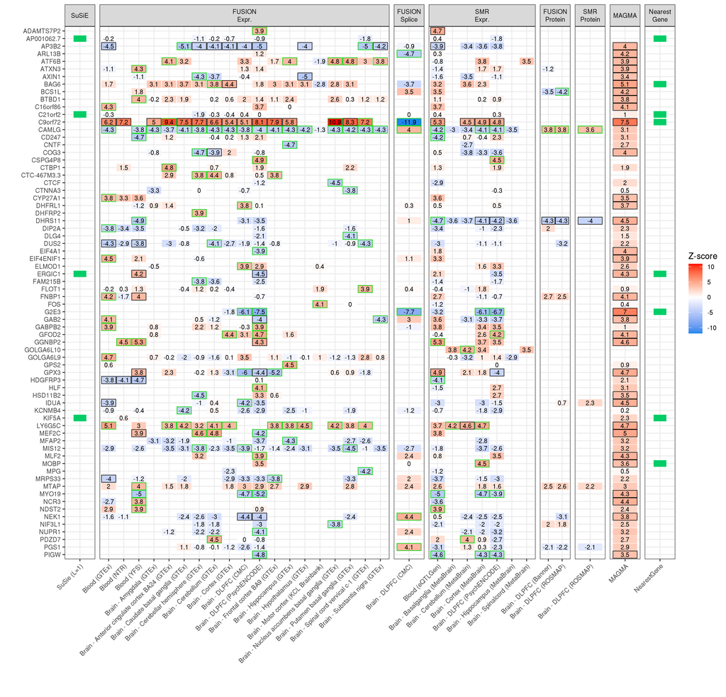

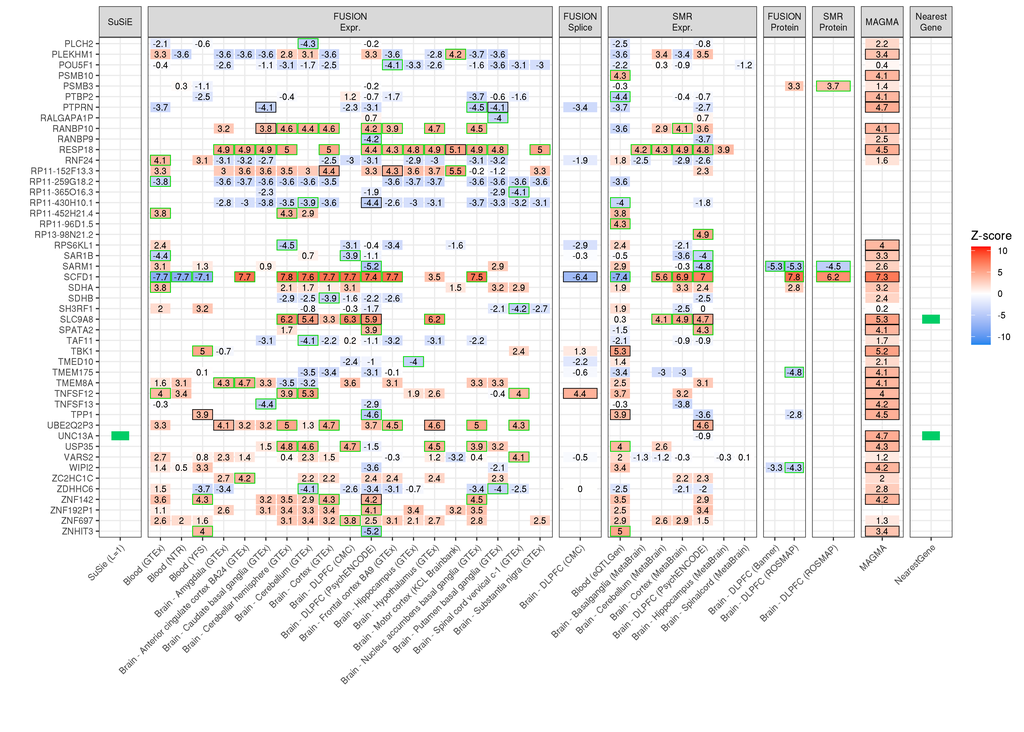

In total, 117 unique genes have been identified as high confidence.

# Drug repurposing

This section shows results drug repurposing analyses. Several analysis approaches are available. The inferred differential expression results from TWAS can be compared to the drug-induced expression profiles from the [Connectivity Map](https://clue.io/), AKA LINCS, to identify drugs that induce expression profiles opposite expression profiles associated with the GWAS phenotype. Two methods are used to compare TWAS and CMAP profiles, including the [average rank based method from So et al.](https://pubmed.ncbi.nlm.nih.gov/28805813/) and [TWAS-GSEA from Pain et al](https://github.com/opain/TWAS-GSEA). An alternative approach is to use MAGMA to identify drugs that are enriched for connections to genes associated with the GWAS phenotype. We use the collection of bipartite gene-drug interactions collated by [DrugTargetor](https://drugtargetor.com/). Unlike the TWAS-CMAP approaches, the MAGMA based approach does not consider the direction of effect of the gene on the GWAS phenotype or the drug on the genes expression/function, so may highlight drugs that might increase risk of the GWAS phenotype. However, the MAGMA approach can use a broader and perhaps more reliable sources of drug-gene interaction databases. To help validate the approaches used for identifying drug repurposing oppurtunities, we test for enrichment of drugs within ATC classifications.

## DGIdb: Drugs interacting with key risk genes

Using the directional associations from TWAS/PWAS and SMR, and drug-gene interaction data from the DGIdb, we have identified drugs that could decrease risk of the GWAS phenotype. I.e. if the GWAS phenotype was associated with an increased expression of a gene, we highlight drugs known to decrease the expression of that risk gene. We only list drug gene interactions for genes that showed a statistically significant and colocalised association with the GWAS phenotype.

**Show Drugs**

| ID | GenePhenoAssoc | Drug | DrugGeneInt | Ref |
| --- | --- | --- | --- | --- |
| PSMB10 | Upregulated | Bortezomib | Inhibitory | link |
| PSMB10 | Upregulated | Oprozomib | Inhibitory | link |
| PSMB10 | Upregulated | Ixazomib citrate | Inhibitory | link |
| PSMB10 | Upregulated | Carfilzomib | Inhibitory | link |
| PSMB10 | Upregulated | Marizomib | Inhibitory | link |
| PSMB3 | Upregulated | Bortezomib | Inhibitory | link |
| PSMB3 | Upregulated | Ixazomib citrate | Inhibitory | link |
| PSMB3 | Upregulated | Oprozomib | Inhibitory | link |
| PSMB3 | Upregulated | Carfilzomib | Inhibitory | link |
| PSMB3 | Upregulated | Marizomib | Inhibitory | link |

Full results file: results/ALS_only/twas/cmap/So_res_clean.csv

Note. ID = Gene ID; GenoPhenoAssoc = Whether the GWAS phenotype is associated with an up or downregulation of the gene; Drug = Drug name; DrugGeneInt = Whether the drug inhibits or activates the gene

## TWAS-DrugTargetor: TWAS-GSEA Method

**Show Top Drug Enrichment Results**

| Drug | Panel | Estimate | SE | P | P.FDR | ATC | Description |
| --- | --- | --- | --- | --- | --- | --- | --- |
| Ribostamycin | Brain_Cerebellum | 0.07 | 0.02 | 3.35e-05 | 2.44e-01 | J01G | aminoglycoside antibacterials |
| Oxymetholone | Brain_Cerebellar_Hemisphere | 0.08 | 0.02 | 3.53e-05 | 2.44e-01 | A14A | anabolic steroids |
| Hyoscyamine | kcl_brainbank_motor_cortex | 0.16 | 0.04 | 8.20e-05 | 3.79e-01 | A03B | belladonna and derivatives, plain |
| Gramicidin | Brain_Cerebellum | -0.06 | 0.02 | 2.18e-04 | 7.56e-01 | R02A | throat preparations |
| Tinzaparin | kcl_brainbank_motor_cortex | -0.16 | 0.04 | 3.00e-04 | 8.33e-01 | B01A | antithrombotic agents |
| Pergolide | kcl_brainbank_motor_cortex | 0.14 | 0.04 | 6.66e-04 | 9.99e-01 | N04B | dopaminergic agents |
| Fendiline | Brain_Anterior_cingulate_cortex_BA24 | -0.09 | 0.03 | 7.02e-04 | 9.99e-01 | C08E | non-selective calcium channel blockers |
| Zuclopenthixol | Brain_Cerebellar_Hemisphere | 0.06 | 0.02 | 8.28e-04 | 9.99e-01 | N05A | antipsychotics |
| Potassium iodide | YFS.BLOOD.RNAARR | 0.06 | 0.02 | 8.86e-04 | 9.99e-01 | R05C | expectorants, excl. combinations with cough suppressants |
| Thioctic acid | Brain_Hippocampus | 0.08 | 0.03 | 8.98e-04 | 9.99e-01 | A16A | other alimentary tract and metabolism products |

[output cut: 240 more lines]

Full results file: results/ALS_only/twas/drugtargetor/twas_gsea_drugtargetor.competitive.clean.csv

**Show ATC Enrichment Results**

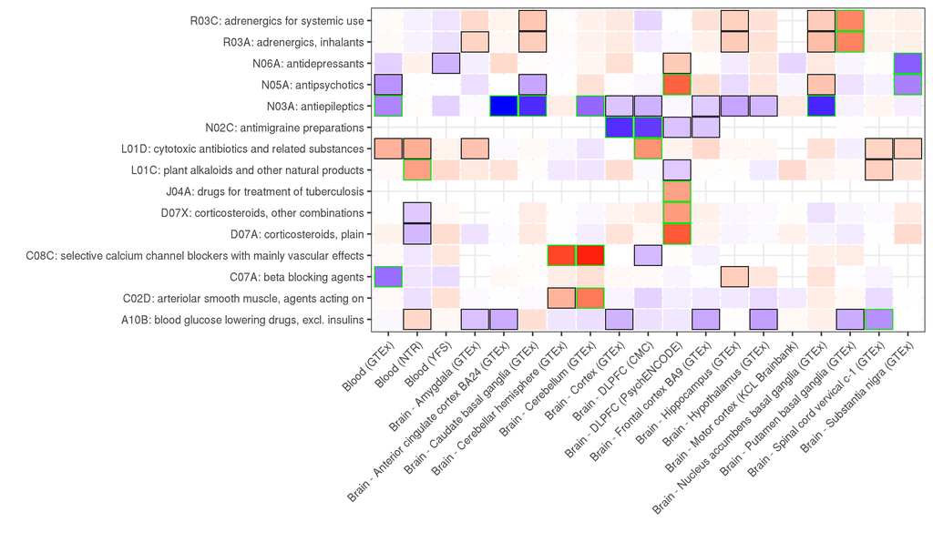

Full results file: results/ALS_only/twas/drugtargetor/twas_gsea_*_res_atc_res.csv

## MAGMA-DrugTargetor

**Show Top Drug Enrichment Results**

| Name | N Genes | BETA | SE | P | P.FDR | ATC Code | ATC Description |
| --- | --- | --- | --- | --- | --- | --- | --- |
| Acadesine | 3 | 1.8243 | 0.56747 | 6.54e-04 | 5.51e-01 | C01E | other cardiac preparations |
| Tocopherol | 1425 | 0.08292 | 0.026267 | 7.99e-04 | 5.51e-01 | A11H | other plain vitamin preparations |
| Ciclopirox | 392 | 0.14782 | 0.048426 | 1.14e-03 | 5.51e-01 | D01A;G01A | antifungals for topical use;antiinfectives and antiseptics, excl. combinations with corticosteroids |
| Cefadroxil | 139 | 0.22096 | 0.077271 | 2.12e-03 | 5.85e-01 | J01D | other beta-lactam antibacterials |
| Rimexolone | 70 | 0.30758 | 0.10842 | 2.28e-03 | 5.85e-01 | H02A;S01B | corticosteroids for systemic use, plain;antiinflammatory agents |
| Trilostane | 4 | 1.0652 | 0.38104 | 2.59e-03 | 5.85e-01 | H02C | antiadrenal preparations |
| Meticrane | 5 | 1.2091 | 0.44122 | 3.07e-03 | 5.85e-01 | C03B | low-ceiling diuretics, excl. thiazides |
| Vigabatrin | 38 | 0.3848 | 0.14121 | 3.22e-03 | 5.85e-01 | N03A | antiepileptics |
| Oxedrine | 16 | 0.6107 | 0.23274 | 4.35e-03 | 6.52e-01 | C01C;S01G | cardiac stimulants excl. cardiac glycosides;decongestants and antiallergics |
| Protriptyline | 30 | 0.39119 | 0.14986 | 4.53e-03 | 6.52e-01 | N06A | antidepressants |

[output cut: 240 more lines]

# References

Please be sure to cite the software and datasets used by this pipeline. Relevent citations are shown below:

**Show reference table**

| Name | PMID | Type | Use |
| --- | --- | --- | --- |
| LD Score Regression | 25642630 | Software | Estimate SNP-h2 and LD-score intercept |
| SuSiE | NA | Software | Variant-level finemapping |
| FUSION | 26854917 | Software | Perform TWAS/PWAS |
| COLOC | 24830394 | Software | Used for colocalisation within FUSION TWAS/PWAS analysis |
| SMR | 29763751 | Software | Infer differential expression or protein levels |
| MAGMA | 25885710 | Software | Estimate gene associations and drug enrichment using DrugTargetor database |
| TWAS-GSEA | 31230729 | Software | Estimate drug enrichment using TWAS and CMAP |
| Average ranks (So et al.) | 28805813 | Software | Estimate drug enrichment using TWAS and CMAP |
| PsychENCODE DLPFC TWAS SNP-weights | 30545856 | Dataset | TWAS |
| PsychENCODE DLPFC eQTL data for SMR | 30545857 | Dataset | SMR |

[output cut: 4 more lines]